# Analysis Workflow of Age Differences in Economic Preferences: Cumulative meta-analyses of risk, time, and social preferences

Alexandra Bagaïni, Yunrui Liu, Arzie Bajrami, Gayoung Son, Loreen Tisdall, Rui Mata

8/1/2022

This document showcases step-by-step the analyses described in the study *Age Differences in Economic Preferences: Cumulative meta-analyses of risk, time, social, and effort preferences*. All the functions that are sourced in this script can be found in the “code/functions/” folder.

### Required packages

```r
# LOADING ALL REQUIRED PACKAGES (FOR SCRIPTS + FUNCTIONS + PLOTTING)
library(tidyverse) # opening/saving files and data wrangling and plotting
library(metafor) # for egger's test
library(dmetar) # to conduct p-curve test
library(janitor) # clean var names
library(esc) # compute effect sizes
library(readxl) # open xlsx file
library(haven) # for reading certain data files
library(foreign) # for reading certain data files
library(effectsize )# compute effect sizes
library(patchwork) # for combining plots
library(data.table) # for data wrangling
library(TOSTER) # for equivalence testing
```

## DATA PROCESSING

We first clean and format the data extracted from the studies included in the meta-analysis and calculate effect sizes. These steps are carried out by specific functions and the outputs are saved into preference-specific folders.

```r
### 1. FORMATTING & PROCESSING ####

# 1A. formatting & processing the file from Covidence containing the extracted data
source("code/functions/covidence_extraction_format.R")

# 1B. formatting & processing raw data (i.e., calculating correlations, means, SDs...)
source("code/functions/processing_raw_data.R")

# 1C. formatting & processing data extracted from plots (using {MetaDigitise})
source("code/functions/processing_plot_data.R")

# 1D. formatting & processing  data from tables
source("code/functions/processing_table_data.R")

### 2. MERGING ####

# Merging output from 1A-1D
source("code/functions/merge_processed_data.R")

### 3. EFFECT SIZES ####

# Using output from 2 to calculate effect sizes
source("code/functions/compute_es.R")

# (re)compute effect sizes from Seaman et al., 2022
source("code/functions/compute_es_seaman_time.R")
```

### Running the data processing workflow

Each set of studies goes through the same processing stages

```r
preferences <- c("risk", "time", "social", "effort")


for (pref in preferences) {

  covidence_extraction_format(preference = pref)
  processing_raw_data(preference = pref)
  processing_plot_data(preference = pref)
  processing_table_data(preference = pref)
  merge_processed_data(preference = pref)
  if (pref == "time" ) {compute_es_seaman_time()}
  compute_es(preference = pref)
}
```

### Exploration & Data Visualisation

```r
# Using outputs from 4 to summarize output
source("code/functions/table_es_pref_overview.R")
```

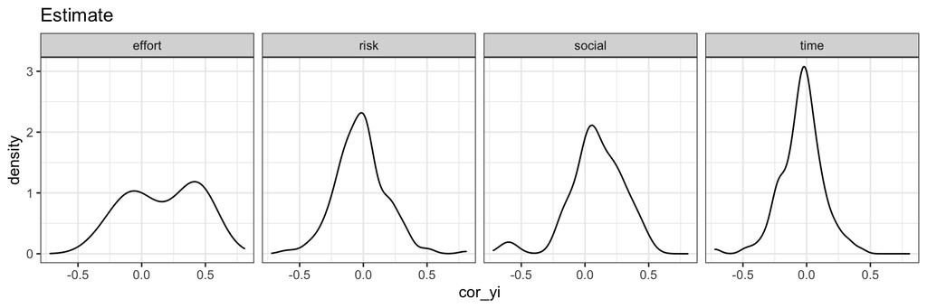

```r
# read workflow output
dat <- bind_rows(read_csv("data/summary/risk/effect_sizes_risk.csv",
                          col_types = cols()),
                 read_csv("data/summary/time/effect_sizes_time.csv",
                          col_types = cols()),
                 read_csv("data/summary/social/effect_sizes_social.csv",
                          col_types = cols()),
                 read_csv("data/summary/effort/effect_sizes_effort.csv",
                          col_types = cols()))

dat %>%
  ggplot(aes(x= cor_yi)) +
  geom_density() +
  facet_wrap(.~pref, nrow = 1)+
  theme_bw() +
  ggtitle("Estimate")
```

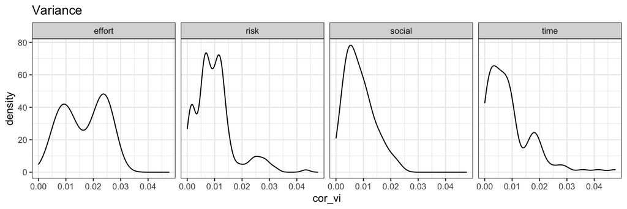

```r
dat %>%
  ggplot(aes(x= cor_vi)) +
  geom_density() +
  facet_wrap(.~pref, nrow = 1)+
  theme_bw()+
  ggtitle("Variance")
```

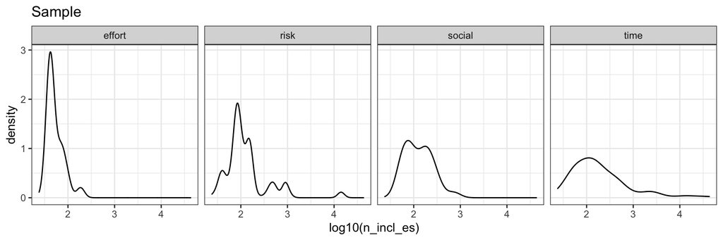

```r
dat %>%
  ggplot(aes(x= log10(n_incl_es))) +
  geom_density() +
  facet_wrap(.~pref, nrow = 1)+
  theme_bw() +
  ggtitle("Sample")
```

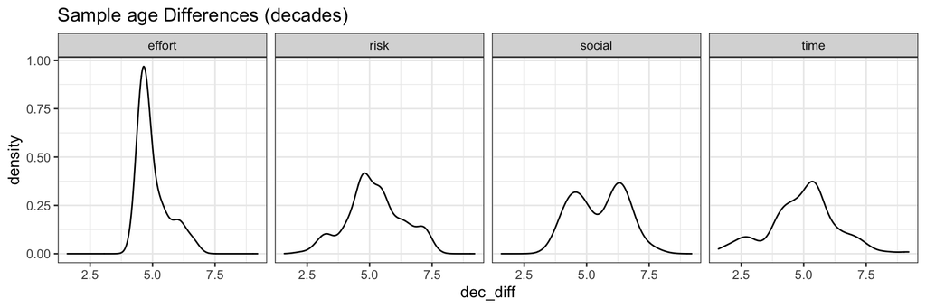

```r
dat %>%
  ggplot(aes(x= dec_diff)) +
  geom_density() +
  facet_wrap(.~pref, nrow = 1)+
  theme_bw() +
  ggtitle("Sample age Differences (decades)")
```

#### Effect Size Overview Table

```r
table1 <- bind_rows(
  table_es_pref_overview(dat = read_csv("data/summary/social/effect_sizes_social.csv",
                                        col_types = cols())),
  table_es_pref_overview(dat = read_csv("data/summary/risk/effect_sizes_risk.csv",
                                        col_types = cols())),
  table_es_pref_overview(dat = read_csv("data/summary/time/effect_sizes_time.csv",
                                        col_types = cols())),
  table_es_pref_overview(dat = read_csv("data/summary/effort/effect_sizes_effort.csv",
                                        col_types = cols()))
)
table1
```

```
## # A tibble: 4 × 6
##   preference n_publications n_studies  n_es n_participants pub_range
##   <chr>               <int>     <int> <int>          <dbl> <chr>
## 1 social                 13        15    28           2997 2012 - 2021
## 2 risk                   57        62   193          39832 1998 - 2022
## 3 time                   50        54   125         115496 1994 - 2022
## 4 effort                  6         7    23            571 2013 - 2021
```

#### Effect Size Risk Overview Table

```r
dat <- read_csv("data/summary/risk/effect_sizes_risk.csv",
                col_types = cols())


### DOMAIN
dat_risk <- dat  %>% mutate(pref = paste0(pref,"_", domain))
bind_rows(
  table_es_pref_overview(dat = filter(dat_risk, pref == "risk_gain")),
  table_es_pref_overview(dat = filter(dat_risk, pref == "risk_loss")),
  table_es_pref_overview(dat = filter(dat_risk, pref == "risk_mixed")))
```

```
## # A tibble: 3 × 6
##   preference n_publications n_studies  n_es n_participants pub_range
##   <chr>               <int>     <int> <int>          <dbl> <chr>
## 1 risk_gain              45        48   106          36617 1998 - 2022
## 2 risk_loss              20        22    46          17249 2001 - 2022
## 3 risk_mixed             20        21    41          18787 2004 - 2022
```

```r
### TASK TYPE
dat_risk <- dat  %>% mutate(pref = paste0(pref,"_", task_type))
bind_rows(table_es_pref_overview(dat = filter(dat_risk, pref == "risk_experience")),
          table_es_pref_overview(dat = filter(dat_risk, pref == "risk_description")),
)
```

```
## # A tibble: 2 × 6
##   preference       n_publications n_studies  n_es n_participants pub_range
##   <chr>                     <int>     <int> <int>          <dbl> <chr>
## 1 risk_experience              17        17    44           3787 2010 - 2022
## 2 risk_description             46        51   147          38167 1998 - 2022
```

## ANALYSES

For each economic preference, we use the output of the data processing workflow to run several analyses. The outputs are saved in saved into preference-specific folders.

```r
### 4. RUN CMA & MA####

# 4A. Using output from 3A to conduct the MLMA + sensitivity analyses
source("code/functions/conduct_mlma.R")
source("code/functions/conduct_sensitivity_rho.R")

# 4B. Using output from 3A to conduct the CMA
source("code/functions/conduct_cma.R") # by study
source("code/functions/conduct_cma_year.R") # by year

# 4C. Using output from 3A to conduct the leave-one-out analysis
source("code/functions/conduct_leave1out.R")
```

### Multilevel Meta-Analysis (MLMA)

We use the effect sizes to fit a three-level meta-analysis model with random effects at the study and estimate level in which we account for the dependence of effect sizes by letting the sampling errors within studies to be correlated with a correlation coefficient of ‘rho’. We also apply robust variance estimation (RVE) with small-sample adjustment.

```r
rho = .5

preferences <- c("risk", "time", "social", "effort")

for (pref in preferences) {

  # read effect size datasets
  dat <- read_csv(sprintf("data/summary/%s/effect_sizes_%s.csv", pref, pref),
                  col_types = cols())

  # fitting multilevel model
  mlma <- conduct_mlma(dat = dat, rho = rho)
  mlma <- robust(mlma, cluster = study_id, clubSandwich = TRUE)

  # save output
  write_rds(mlma, sprintf("output/%s/mlma_%s.rds", pref, pref))
}
```

##### Additional risk analyses

Additional analyses for risk: Splitting by domain and task type

```r
rho = .5
pref = "risk"
dat <- read_csv(sprintf("data/summary/%s/effect_sizes_%s.csv", pref, pref),col_types = cols())

##### DOMAIN
table(dat$domain)


domains <- c("gain", "loss", "mixed")

for (dom in domains) {

  # filter effect size datasets
  sdat <- dat %>% filter(domain == dom) %>%
    mutate(pref = paste0(pref,"_", dom))


  # fitting multilevel model
  mlma <- conduct_mlma(dat = sdat, rho = rho)
  mlma <- robust(mlma, cluster = study_id, clubSandwich = TRUE)


  # save output
  write_rds(mlma, sprintf("output/%s/mlma_%s_%s.rds", pref, pref, dom))
}


##### TASK TYPE
table(dat$task_type)

types <- c("description", "experience")

for (typ in types) {

  # filter effect size datasets
  sdat <- dat %>% filter(task_type == typ) %>%
    mutate(pref = paste0(pref,"_", typ))


  # fitting multilevel model
  mlma <- conduct_mlma(dat = sdat, rho = rho)
  mlma <- robust(mlma, cluster = study_id, clubSandwich = TRUE)


  # save output
  write_rds(mlma, sprintf("output/%s/mlma_%s_%s.rds", pref, pref, typ))
}
```

##### Additional social analyses

Running the re-analysis of the Sparrow et al. (2021) dataset.

```r
source("code/01_sparrow_ma_reanalysis.R")
```

```
## [[1]]
## [1] "Reported overall effect size"
##
## [[2]]
##
## Random-Effects Model (k = 16; tau^2 estimator: REML)
##
## tau^2 (estimated amount of total heterogeneity): 0.0171 (SE = 0.0227)
## tau (square root of estimated tau^2 value):      0.1309
## I^2 (total heterogeneity / total variability):   27.38%
## H^2 (total variability / sampling variability):  1.38
##
## Test for Heterogeneity:
## Q(df = 15) = 25.2440, p-val = 0.0468
##
## Model Results:
##
## estimate      se    zval    pval   ci.lb   ci.ub
##   0.6064  0.0645  9.4072  <.0001  0.4801  0.7327  ***
##
## ---
## Signif. codes:  0 '***' 0.001 '**' 0.01 '*' 0.05 '.' 0.1 ' ' 1
##
##
## [[1]]
## [1] "Corrected overall effect size"
##
## [[2]]
##
## Random-Effects Model (k = 16; tau^2 estimator: REML)
##
## tau^2 (estimated amount of total heterogeneity): 0.2123 (SE = 0.0986)
## tau (square root of estimated tau^2 value):      0.4608
## I^2 (total heterogeneity / total variability):   82.37%
## H^2 (total variability / sampling variability):  5.67
##
## Test for Heterogeneity:
## Q(df = 15) = 92.2075, p-val < .0001
##
## Model Results:
```

[output cut: 15 more lines]

```
## tau^2 (estimated amount of total heterogeneity): 0.0491 (SE = 0.0217)
## tau (square root of estimated tau^2 value):      0.2217
## I^2 (total heterogeneity / total variability):   85.67%
## H^2 (total variability / sampling variability):  6.98
##
## Test for Heterogeneity:
## Q(df = 15) = 137.0977, p-val < .0001
##
## Model Results:
##
## estimate      se    zval    pval   ci.lb   ci.ub
##   0.2353  0.0610  3.8542  0.0001  0.1156  0.3549  ***
##
## ---
## Signif. codes:  0 '***' 0.001 '**' 0.01 '*' 0.05 '.' 0.1 ' ' 1
```

### Equivalence Testing

To assess whether the effect sizes we obtained are practically or theoretically of *relevance* (i.e., does the overall effect size fall within the boundaries of a smallest effect size of interest or not?) we conducted equivalence tests. We determined the smallest effect size of interest to be |.1|

```r
preferences <- c("time", "risk", "social", "effort")
for (pref in preferences) {

  m <- read_rds(sprintf("output/%s/mlma_%s.rds", pref, pref))

  rob_se <- m$se
  es <- m$b[1]

  t <- TOSTmeta(ES = es,
                se = rob_se,
                low_eqbound_d=-0.1,
                high_eqbound_d=0.1,
                alpha=0.05)

  # save output
  write_rds(t, sprintf("output/%s/equivalence_test_%s.rds", pref ,pref))
}
```

##### Additional risk analyses

Additional analyses for risk: Splitting by domain and task type

```r
pref = "risk"

domains <- c("gain", "loss", "mixed")

for (dom in domains) {

  m <- read_rds(sprintf("output/%s/mlma_%s_%s.rds", pref, pref, dom))

  rob_se <- m$se
  es <- m$b[1]

  t <- TOSTmeta(ES = es,
                se = rob_se,
                low_eqbound_d = -0.1,
                high_eqbound_d = 0.1,
                alpha=0.05)

  # save output
  write_rds(t, sprintf("output/%s/equivalence_test_%s_%s.rds", pref ,pref, dom))



}


##### TASK TYPE
types <- c("description", "experience")

for (typ in types) {


  m <- read_rds(sprintf("output/%s/mlma_%s_%s.rds", pref, pref, typ))

  rob_se <- m$se
  es <- m$b[1]

  t <- TOSTmeta(ES = es,
                se = rob_se,
                low_eqbound_d = -0.1,
                high_eqbound_d = 0.1,
                alpha=0.05)

  # save output
  write_rds(t, sprintf("output/%s/equivalence_test_%s_%s.rds", pref ,pref, typ))

}
```

### Sensitivity Analyses

As it is difficult to know exactly the correlation of sampling errors within clusters, we also run sensitivity analyses for each set of effect sizes, by specifying different values of ‘rho’.

```r
rho_vec <- seq(from = .1, to = .9, by = .1)
preferences <- c("risk", "time", "social", "effort")

for (pref in preferences) {

  # read effect size dataset
  dat <- read_csv(sprintf("data/summary/%s/effect_sizes_%s.csv", pref, pref),
                  col_types = cols())

  # fitting ml model with different rho values
  rho_test <- conduct_sensitivity_rho(dat = dat, rho_vec = rho_vec)

  # save output
  write_rds(rho_test, sprintf("output/%s/mlma_sensitivity_rho_%s.rds", pref, pref))
}
```

### Egger’s regression test

To check for publication bias, we run an Egger’s regression test with either the standard error or the incerse sample size as the precision metric.

```r
rho = .5
preferences <- c("time", "risk", "social", "effort")
for (pref in preferences) {
  egger_df <- NULL
  for (preci in c("se", "invn")) {

    # read effect size datasets
    dat <- read_csv(sprintf("data/summary/%s/effect_sizes_%s.csv", pref, pref),
                    col_types = cols())
    dat <- escalc(yi = cor_yi, vi = cor_vi, data = dat)
    dat$study_id <- as.character(dat$study_id)
    dat$es_id <- as.character(dat$es_id)

    # compute a "precision" index (standard error or inverse sample size)

    if (preci == "se") {
      dat$precision <- sqrt(dat$cor_vi)
    }
    if (preci == "invn") {
      dat$precision <- 1/dat$n_incl_es
    }

    # run meta-regression with "precision" as a predictor

    ### create approx. V matrix assuming that the effect sizes within studies
    ###  are correlated with a correlation coefficient of value 'rho'
    V_mat <- vcalc(vi = vi,
                   cluster = study_id,
                   obs = es_id,
                   data = dat,
                   rho = rho)

    ### Egger's Test: fit multilevel model using the approximate V matrix +
    ### predictor to represent precision
    egger <- rma.mv(yi ~ 1 + precision,
                    V = V_mat,
                    random = ~ 1| study_id/es_id,
                    data = dat)

    # apply RVE
    egger <- robust(egger, cluster = study_id, clubSandwich = TRUE)


    # could also use broom::tidy()
    res_df <- tibble(precision_indc = preci,
                     moderator = rownames(egger$b),
                     estimate = egger$b[,1],
                     se = egger$se,
                     tval = egger$zval,
                     ci_lb = egger$ci.lb,
                     ci_ub = egger$ci.ub,
                     pval = egger$pval)


    egger_df <- bind_rows(egger_df,res_df)
  }

  # save output
  write_rds(egger_df, sprintf("output/%s/egger_%s.rds", pref ,pref))
}
```

### P-Curve Analysis

To check for evidence of p-hacking, we conduct a pcurve test for each set of effect sizes.

```r
preferences <- c("risk", "time", "social", "effort")
for (pref in preferences) {

  # read effect size datasets
  dat <- read_csv(sprintf("data/summary/%s/effect_sizes_%s.csv", pref, pref),
                  col_types = cols())

  # Create p-curve compatible df. object
  pcurve_obj <- tibble("studlab" = dat$study_label,
                       "seTE"    = sqrt(dat$cor_vi),
                       "TE"      = dat$cor_yi)

  # Run p-curve test using dmetar package
  pcurve_t <- dmetar::pcurve(pcurve_obj)

  # save output
  write_rds(pcurve_t, sprintf("output/%s/pcurve_%s.rds", pref, pref))
}
```

### Cumulative Meta-Analysis

#### Study Level

For the study-level cumulative meta-analysis, we added the effect size(s) of one study after the other in order of year of publication, and each time we fit the same three-level model specified above.

```r
rho = .5 # set correlation for variances

preferences <- c("risk", "time", "social", "effort")

for (pref in preferences) {

  # read effect size dataset
  dat <- read_csv(sprintf("data/summary/%s/effect_sizes_%s.csv", pref, pref),
                  col_types = cols())


  # apply robust variance estimation
  cma <- conduct_cma(dat = dat, rho = rho, rve = TRUE)


  write_rds(cma, sprintf("output/%s/cma_study_%s.rds", pref, pref))

}
```

##### Additional analyses for risk

Additional analyses for risk: Splitting risk by domain and task type

```r
rho = .5
pref = "risk"
dat <- read_csv(sprintf("data/summary/%s/effect_sizes_%s.csv", pref, pref),
                col_types = cols())


##### DOMAIN
table(dat$domain)

#ignoring frame
domains <- c("gain", "loss", "mixed")

for (dom in domains) {

  # filter effect size datasets
  sdat <- dat %>% filter(domain == dom) %>%
    mutate(pref = paste0(pref,"_", dom))


  # apply robust variance estimation
  cma <- conduct_cma(dat = sdat, rho = rho, rve = TRUE)


  write_rds(cma, sprintf("output/%s/cma_study_%s_%s.rds", pref, pref, dom))


}

##### TASK TYPE
table(dat$task_type)

types <- c("description", "experience")

for (typ in types) {

  # filter effect size datasets
  sdat <- dat %>% filter(task_type == typ) %>%
    mutate(pref = paste0(pref,"_", typ))

  # apply robust variance estimation
  cma <- conduct_cma_year(dat = sdat, rho = rho, rve = TRUE)

  write_rds(cma, sprintf("output/%s/cma_study_%s_%s.rds", pref, pref, typ))

}
```

#### Year Level

For the year-level cumulative meta-analysis, we added the effect size(s) published in one same year after the next, and each time we fit the same three-level model specified above.

```r
rho = .5 # set correlation for variances

preferences <- c("risk", "time", "social", "effort")

for (pref in preferences) {

  # read effect size dataset
  dat <- read_csv(sprintf("data/summary/%s/effect_sizes_%s.csv", pref, pref),
                  col_types = cols())

  # apply robust variance estimation
  cma <- conduct_cma_year(dat = dat, rho = rho, rve = TRUE)


  write_rds(cma, sprintf("output/%s/cma_year_%s.rds", pref, pref))

}
```

##### Additional analyses for risk

Additional analyses for risk: Splitting risk by domain and task type

```r
rho = .5
pref = "risk"
dat <- read_csv(sprintf("data/summary/%s/effect_sizes_%s.csv", pref, pref),
                col_types = cols())


###### DOMAIN
table(dat$domain)


domains <- c("gain", "loss", "mixed")

for (dom in domains) {

  # filter effect size datasets
  sdat <- dat %>% filter(domain == dom) %>%
    mutate(pref = paste0(pref,"_", dom))

  # apply robust variance estimation
  cma <- conduct_cma_year(dat = sdat, rho = rho, rve = TRUE)


  write_rds(cma, sprintf("output/%s/cma_year_%s_%s.rds", pref, pref, dom))

}



##### TASK TYPE
table(dat$task_type)

types <- c("description", "experience")

for (typ in types) {

  # filter effect size datasets
  sdat <- dat %>% filter(task_type == typ) %>%
    mutate(pref = paste0(pref,"_", typ))

  # apply robust variance estimation
  cma <- conduct_cma_year(dat = sdat, rho = rho, rve = TRUE)

  write_rds(cma, sprintf("output/%s/cma_year_%s_%s.rds", pref, pref, typ))
}
```

### Leave-One-Out Analysis

To explore whether some studies are more influential than others, we fit the three-level model by omitting one study at a time.

```r
rho = .5 # set correlation for variances

preferences <- c("risk", "time", "social", "effort")

for (pref in preferences) {

  # read effect size dataset
  dat <- read_csv(sprintf("data/summary/%s/effect_sizes_%s.csv", pref, pref),
                  col_types = cols())

  # conduct leave one out
  leave1out <- conduct_leave1out(dat = dat, rho = rho, rve = TRUE)

  write_rds(leave1out, sprintf("output/%s/leave1out_study_%s.rds", pref, pref))


}
```

### Meta-Regressions

Here we fit several three-level meta-regression models to investigate the role of different moderators.

```r
source("code/01_meta_regressions.R")
```

#### Covariate overview

Below is a list of the number of effect sizes (for each econ. preference) broken down into the different levels of the categorical moderator that were included in the meta-regressions

```r
covariates <- c("incentivization", "domain", "task_type", "cor_type", "study_design", "study_context", "effort_type")

preferences <- c("risk", "social", "time", "effort")

for (pref in preferences) {

  # read effect size datasets
  dat <- read_csv(sprintf("data/summary/%s/effect_sizes_%s.csv", pref, pref),
                  col_types = cols())

  df <- NULL
  for (covar in covariates) {

    if (pref != "effort" & covar == "effort_type")
      next


    dt <- dat %>%
      group_by_at(covar) %>%
      summarise(k = n(),
                pref = unique(dat$pref),
                predictor = covar) %>%
      rename("level" = all_of(covar))

    df <- bind_rows(df, dt)
  }

  print(df)

  write_csv(df, sprintf("output/%s/covariate_overview_%s.csv", pref, pref))

}
```

```
## # A tibble: 15 × 4
##    level             k pref  predictor
##    <chr>         <int> <chr> <chr>
##  1 hypothetical     41 risk  incentivization
##  2 incentivized    127 risk  incentivization
##  3 unknown          25 risk  incentivization
##  4 gain            106 risk  domain
##  5 loss             46 risk  domain
##  6 mixed            41 risk  domain
##  7 description     147 risk  task_type
##  8 experience       44 risk  task_type
##  9 mixed             2 risk  task_type
## 10 COR              72 risk  cor_type
## 11 RPB             121 risk  cor_type
## 12 continuous       39 risk  study_design
```

[output cut: 45 more lines]

### Temporal Trends: Effect Sizes

To assess if effect sizes and year of publication are linked, we fit a three-level meta regression with year of publication as the predictor.

```r
rho = .5
preferences <- c("time", "risk", "social", "effort")

for (pref in preferences) {

  # read effect size dataset
  dat <- read_csv(sprintf("data/summary/%s/effect_sizes_%s.csv", pref, pref),
                  col_types = cols())

  dat <- dat %>% mutate(dec_in_print = (2022 - year_of_publication)/10)

  # transform data into an escalc object
  dat <- escalc(yi = cor_yi, vi = cor_vi, data = dat )

  # create approx. V matrix assuming that the effect sizes within studies are correlated with a correlation coefficient of value 'rho'
  V_mat <- vcalc(vi = vi,
                 cluster = study_id,
                 obs = es_id,
                 data = dat,
                 rho = rho)

  # fit multilevel model using approximate V matrix
  ## year of publication as moderator
  temp_m <- rma.mv(yi ~ 1 + dec_in_print,
                   V = V_mat,
                   random = ~ 1 | study_id/es_id, # random effect of study and estimate
                   data= dat)
  temp_m <- robust(temp_m, cluster = study_id, clubSandwich = TRUE)

  write_rds(temp_m, sprintf("output/%s/temp_trend_%s.rds", pref, pref))
}
```

##### Additional risk analyses

Additional analyses for risk: Splitting risk by domain and task type.

```r
rho =.5
pref = "risk"
dat <- read_csv(sprintf("data/summary/%s/effect_sizes_%s.csv", pref, pref),
                col_types = cols())

table(dat$domain)

domains <- c("gain", "loss", "mixed")

for (dom in domains) {

  # filter effect size datasets
  sdat <- dat %>% filter(domain == dom) %>%
    mutate(pref = paste0(pref,"_", dom),
           dec_in_print = (2022 - year_of_publication)/10)

  sdat <- escalc(yi = cor_yi, vi = cor_vi, data = sdat )


  # create approx. V matrix assuming that the effect sizes within studies are correlated with a correlation coefficient of value 'rho'
  V_mat <- vcalc(vi = vi,
                 cluster = as.character(study_id),
                 obs = as.character(es_id),
                 data = sdat,
                 rho = rho)

  # fit multilevel models using approximate V matrix
  ## year of publication as moderator
  temp_m <- rma.mv(yi ~ 1 + dec_in_print,
                   V = V_mat,
                   random = ~ 1 | study_id/es_id, # random effect of study and estimate
                   data= sdat)


  temp_m <- robust(temp_m, cluster = study_id, clubSandwich = TRUE)


  write_rds(temp_m, sprintf("output/%s/temp_trend_%s_%s.rds", pref, pref, dom))
}



##### TASK TYPE
table(dat$task_type)

types <- c("description", "experience")

for (typ in types) {

  # filter effect size datasets
  sdat <- dat %>% filter(task_type == typ) %>%
    mutate(pref = paste0(pref,"_", typ),
           dec_in_print = (2022 - year_of_publication)/10)


  sdat <- escalc(yi = cor_yi, vi = cor_vi, data = sdat )


  # create approx. V matrix assuming that the effect sizes within studies are correlated with a correlation coefficient of value 'rho'
  V_mat <- vcalc(vi = vi,
                 cluster = as.character(study_id),
                 obs = as.character(es_id),
                 data = sdat,
                 rho = rho)

  # fit multilevel models using approximate V matrix
  ## year of publication as moderator
  m <- rma.mv(yi ~ 1 + dec_in_print,
              V = V_mat,
              random = ~ 1 | study_id/es_id, # random effect of study and estimate
              data= sdat)

  write_rds(m, sprintf("output/%s/temp_trend_%s_%s.rds", pref, pref, typ))
}
```

### Temporal Trends: Sample Sizes

To assess if sample sizes and year of publication are linked, we fit a simple linear with year of publication as the predictor and sample size as the dependent variable.

```r
# source function to create data frame with sample sizes
source("code/functions/table_sample_sizes.R")


preferences <- c("time", "risk", "social", "effort")


for (pref in preferences) {

  # read effect size dataset
  dat <- read_csv(sprintf("data/summary/%s/effect_sizes_%s.csv", pref, pref),
                  col_types = cols())


  dat_n <- table_sample_sizes(dat = dat)
  dat_n <- dat_n %>% mutate(dec_in_print = -(2022 - year_of_publication)/10,
                            n_incl_es_log = log10(n_incl_es))

  # fit a simple linear regression model
  temp_m <- lm(n_incl_es_log ~ 1 + dec_in_print, data = dat_n)

  temp_m$data <- dat_n
  write_rds(temp_m, sprintf("output/%s/temp_trend_sample_%s.rds", pref, pref))
}
```

### Proteus Phenomenon: Time Preference

We followed the approach by Koricheva et al. (2013) and compared the effect size and variance of the first study (i.e., Green 1994) with the mean effect size and variance of the rest of the studies.

```r
# get data
dat <- read_csv("data/summary/time/effect_sizes_time.csv",col_types = cols())

# transform data into an escalc object
dat <- escalc(yi = cor_yi, vi = cor_vi, data = dat )

green_dat <- dat %>% filter(grepl("reen", study_label)) # first study
other_dat <- dat %>% filter(!grepl("reen", study_label)) # other studies

# create approx. V matrix assuming that the effect sizes within studies are correlated with a correlation coefficient of value 'rho'
V_mat <- vcalc(vi = vi,
               cluster = study_id,
               obs = es_id,
               data = other_dat,
               rho = .5)

m_oth <- rma.mv(yi = yi,
                V = V_mat,
                random = ~ 1 | study_id/es_id, # random effect of study and estimate
                data=other_dat,
                digits=4)

# calculate z value
z_val <- (m_oth$b[1] - green_dat$cor_yi)/sqrt(green_dat$cor_vi + m_oth$se[1])
z_val
```

```
## [1] 2.70524
```

```r
# 2-sided test
p_val <- 2*pnorm(-abs(z_val))
p_val
```

```
## [1] 0.006825498
```

### Proteus Phenomenon: Effort Discounting

We followed the approach by Koricheva et al. (2013) and compared the effect size and variance of the first article (Westbrook et at., 2013) with the mean effect size and variance of the rest of the studies.

```r
# get data
dat <- read_csv("data/summary/effort/effect_sizes_effort.csv",col_types = cols())

# transform data into an escalc object
dat <- escalc(yi = cor_yi, vi = cor_vi, data = dat )

westbrook_dat <- dat %>% filter(grepl("Westbrook", study_label)) # first study
other_dat <- dat %>% filter(!grepl("Westbrook", study_label)) # other studies

# create approx. V matrix assuming that the effect sizes within studies are correlated with a correlation coefficient of value 'rho'
V_mat <- vcalc(vi = vi,
               cluster = study_id,
               obs = es_id,
               data = westbrook_dat,
               rho = .5)

m_westbrook <- rma.mv(yi = yi,
                      V = V_mat,
                      random = ~ 1 | study_id/es_id, # random effect of study and estimate
                      data=westbrook_dat,
                      digits=4)

V_mat <- vcalc(vi = vi,
               cluster = as.factor(study_id),
               obs = as.factor(es_id),
               data = other_dat,
               rho = .5)


m_oth <- rma.mv(yi = yi,
                V = V_mat,
                random = ~ 1 | study_id/es_id, # random effect of study and estimate
                data=other_dat,
                digits=4)

# calculate z value
z_val <- (m_oth$b[1] - m_westbrook$b[1])/sqrt(m_westbrook$se[1] + m_oth$se[1])
z_val
```

```
## [1] -0.8875023
```

```r
# 2-sided test
p_val <- 2*pnorm(-abs(z_val))
p_val
```

```
## [1] 0.3748085
```

### Citations

Using citation data from Google Scholar we analysed the link between an article’s yearly citation count with its (aggregated) effect size and (average) sample size.

```r
source("code/01_cit_regression.R")
```

## PLOTTING

Here we use the data processing and analysis output and create forest plots and other figures to either display results, have an overview of effect sizes, or illustrate the absence/presence of publication bias.

```r
### 5. PLOT CMA & MA ####

# Plotting CMA results
source("code/functions/plot_forestplot_cma.R")
source("code/functions/plot_year_cma.R")

# Plotting MA results
source("code/functions/plot_forestplot_ma.R")
source("code/functions/plot_year_ma.R")

# Plotting temporal trends
source("code/functions/plot_temp_trend.R")
source("code/functions/plot_temp_trend_sample.R")

# Plotting leave-one-out results
source("code/functions/plot_forestplot_leave1out.R")

# Plotting funnel plot
source("code/functions/plot_funnelplot.R")
source("code/functions/plot_contour_funnelplot.R")

# Plotting pcurve plot
source("code/functions/plot_pcurve.R")

# Plotting distributions
source("code/functions/plot_distrib.R")

# Plotting sensitivity plot
source("code/functions/plot_sensitivity_rho.R")

# Plotting citation analysis
source("code/functions/plot_citation_trends.R")

# Plotting equivalence test
source("code/functions/plot_equivalence_test.R")
```

### Plot Effect Sizes By Year: MA + CMA + Temporal Trends (Figure 1)

```r
# cma plots
cma_p <- plot_year_cma(m_list = c("output/risk/cma_year_risk.rds",
                                  "output/time/cma_year_time.rds",
                                  "output/social/cma_year_social.rds",
                                  "output/effort/cma_year_effort.rds"))+
  labs(title = "C. Cumulative Effect Sizes")


#  yearly es plots
ma_p <- plot_year_ma(m_list = c("output/risk/mlma_risk.rds",
                                "output/time/mlma_time.rds",
                                "output/social/mlma_social.rds",
                                "output/effort/mlma_effort.rds")) +
  labs(title = "B. Effect Sizes by Year")


# temporal trends
temp_p <- plot_temp_trend(m_list = c("output/risk/temp_trend_risk.rds",
                                     "output/time/temp_trend_time.rds",
                                     "output/social/temp_trend_social.rds",
                                     "output/effort/temp_trend_effort.rds")) +
  labs(title = "A. Individual Effect Sizes")

# merge plots
p <-  temp_p+
  ( ma_p+ theme(strip.text = element_text(color = "white")))+
  (cma_p + theme(strip.text = element_text(color = "white")))


ggsave("figures/es_year.png", plot = p, width = 17, height = 15, units = "cm", dpi = 600)
```

#### Additional plots for risk: Splitting by Domain & Task Type (Suppl. Figures)

```r
### DOMAIN

# cma plots
cma_p <- plot_year_cma(m_list = c("output/risk/cma_year_risk_loss.rds",
                                  "output/risk/cma_year_risk_gain.rds",
                                  "output/risk/cma_year_risk_mixed.rds"))+
  labs(title = "C. Cumulative Effect Sizes")


# yearly es plots
ma_p <- plot_year_ma(m_list = c("output/risk/mlma_risk_loss.rds",
                                "output/risk/mlma_risk_gain.rds",
                                "output/risk/mlma_risk_mixed.rds")) +
  labs(title = "B. Effect Sizes by Year")




# temporal trend with effect sizes plots
temp_p <- plot_temp_trend(m_list= c("output/risk/temp_trend_risk_loss.rds",
                                    "output/risk/temp_trend_risk_gain.rds",
                                    "output/risk/temp_trend_risk_mixed.rds")) +
  labs(title = "A. Individual Effect Sizes")

# merge plots
p <- temp_p +
  ( ma_p+ theme(strip.text = element_text(color = "white")))+
  (cma_p + theme(strip.text = element_text(color = "white")))


ggsave("figures/es_risk_year.png", plot = p, width = 25, height = 15, units = "cm", dpi = 600)


#### TASK TYPE

# cma plots
cma_p <- plot_year_cma(m_list = c("output/risk/cma_year_risk_experience.rds",
                                  "output/risk/cma_year_risk_description.rds"))+
  labs(title = "C. Cumulative Effect Sizes")


# es year plots
ma_p <- plot_year_ma(m_list = c("output/risk/mlma_risk_experience.rds",
                                "output/risk/mlma_risk_description.rds")) +
  labs(title = "B. Effect Sizes by Year")




# trend plots
temp_p <- plot_temp_trend(m_list= c("output/risk/temp_trend_risk_experience.rds",
                                    "output/risk/temp_trend_risk_description.rds")) +
  labs(title = "A. Individual Effect Sizes")

# merge plots
p <- temp_p+
  (ma_p + theme(strip.text = element_text(color = "white")))+
  (cma_p + theme(strip.text = element_text(color = "white")))





ggsave("figures/es_risk_type_year.png", plot = p, width = 25, height = 11, units = "cm", dpi = 600)
```

### Equivalence Tests (Figure 2)

```r
pA <- plot_equivalence_test(m_file_list = c("output/risk/mlma_risk.rds",
                                            "output/effort/mlma_effort.rds",
                                            "output/time/mlma_time.rds",
                                            "output/social/mlma_social.rds"),
                            low_eq = -.1, high_eq = .1)

pA <- pA + labs(tag = "A", x = "") +
  theme(plot.tag = element_text(size = 11, family = "Arial", face = "bold"))

pB <- plot_equivalence_test(m_file_list =  c("output/risk/mlma_risk_gain.rds",
                                             "output/risk/mlma_risk_loss.rds",
                                             "output/risk/mlma_risk_mixed.rds"),
                            low_eq = -.1, high_eq = .1)

pB <- pB + labs(tag = "B", x = "") +
  theme(plot.tag = element_text(size = 11, family = "Arial", face = "bold"))

pC <- plot_equivalence_test(m_file_list =  c("output/risk/mlma_risk_experience.rds",
                                             "output/risk/mlma_risk_description.rds"),
                            low_eq = -.1, high_eq = .1)

pC <- pC + labs(tag = "C") +
  theme(plot.tag = element_text(size = 11, family = "Arial", face = "bold"))


p <- (pA/pB/pC)  +
  plot_layout(heights = c(.75,.5, .3))


ggsave("figures/equivalence_test.png", plot = p, width = 19, height = 17, units = "cm", dpi = 600)
```

### Overview of Effect Sizes & Sample Sizes (Suppl. Figure)

```r
# source function to create data frame with sample sizes
source("code/functions/table_sample_sizes.R")

# PREFERENCES
dat <- bind_rows(read_csv("data/summary/risk/effect_sizes_risk.csv",
                          col_types = cols()),
                 read_csv("data/summary/time/effect_sizes_time.csv",
                          col_types = cols()),
                 read_csv("data/summary/social/effect_sizes_social.csv",
                          col_types = cols()),
                 read_csv("data/summary/effort/effect_sizes_effort.csv",
                          col_types = cols())) %>%
  rename(val = cor_yi)

pA <- plot_distrib(dat) +
  labs(x= "Effect Size (cor)", tag = "A") +
  geom_vline(xintercept = 0, linetype = "dotted", color = "grey30")+
  scale_x_continuous(breaks = seq(-1,1,.5), limits = c(-1,1)) +
  theme(plot.tag = element_text(size = 11, family = "Arial", face = "bold"),
        plot.tag.position = c(.1, 1.05),
        plot.margin = margin(r = 5, t = 12))

# sample sizes
dat_n <- table_sample_sizes(dat) %>%
  mutate(val = n_incl_es)

pB <- plot_distrib(dat_n) +
  labs(x= "Sample Size (log10)", tag = "B") +
  theme( plot.margin = margin(r = 5, t = 12),
         plot.tag.position = c(.1, 1.05),
         plot.tag = element_text(size = 11, family = "Arial", face = "bold"))+
  scale_x_log10(limits = c(10,20000))



### RISK: DOMAIN
dat <-read_csv("data/summary/risk/effect_sizes_risk.csv",
               col_types = cols())%>%
  mutate(pref = paste0(pref, ": ", domain)) %>%
  rename(val = cor_yi)

pC <- plot_distrib(dat) +
  labs(x= "", tag = "C") +
  geom_vline(xintercept = 0, linetype = "dotted", color = "grey30")+
  scale_x_continuous(breaks = seq(-1,1,.5), limits = c(-1,1)) +
  theme(plot.margin = margin(r = 5, t = 12),
        axis.text.y = element_blank(),
        axis.title.y = element_blank(),
        plot.tag.position = c(.01, 1.05),
        plot.tag = element_text(size = 11, family = "Arial", face = "bold"))

dat_n <- table_sample_sizes(dat) %>%
  mutate(val = n_incl_es)

pD <- plot_distrib(dat_n) +
  labs(x= "", tag = "D") +
  theme(
    plot.margin = margin(r = 5, t = 12),
    axis.text.y = element_blank(),
    axis.title.y = element_blank(),
    plot.tag.position = c(.01, 1.05),
    plot.tag = element_text(size = 11, family = "Arial", face = "bold"))+
  scale_x_log10(limits = c(10,20000))

### RISK: TASK
dat <-read_csv("data/summary/risk/effect_sizes_risk.csv",
               col_types = cols())%>%
  filter(task_type != "mixed") %>%
  mutate(pref = paste0(pref, ":\n", task_type)) %>%
  rename(val = cor_yi)

pE <- plot_distrib(dat) +
  labs(x= "", tag = "E") +
  geom_vline(xintercept = 0, linetype = "dotted", color = "grey30")+
  scale_x_continuous(breaks = seq(-1,1,.5), limits = c(-1,1)) +
  theme(
    plot.margin = margin(t = 12),
    axis.text.y = element_blank(),
    axis.title.y = element_blank(),
    plot.tag.position = c(.01, 1.05),
    plot.tag = element_text(size = 11, family = "Arial", face = "bold"))

dat_n <- table_sample_sizes(dat) %>%
  mutate(val = n_incl_es)

pF <- plot_distrib(dat_n) +
  labs(x= "", tag = "F") +
  theme(
    plot.margin = margin(t = 12),
    axis.text.y = element_blank(),
    axis.title.y = element_blank(),
    plot.tag.position = c(.01, 1.05),
    plot.tag = element_text(size = 11, family = "Arial", face = "bold"))+
  scale_x_log10(limits = c(10,20000))






p <- (pA+ pC + pE)/ (pB+ pD+ pF)

ggsave("figures/es_sample_overview.png", plot = p, width = 29, height = 18, units = "cm", dpi = 600)
```

### CMA + (ML)MA study-level forestplots (Suppl. Figure)

```r
# cma plots
cma_p_r <- plot_forestplot_cma(m = read_rds("output/risk/cma_study_risk.rds"))

cma_p_t <- plot_forestplot_cma(m = read_rds("output/time/cma_study_time.rds"))

cma_p_a <- plot_forestplot_cma(m = read_rds("output/social/cma_study_social.rds"))

cma_p_e <- plot_forestplot_cma(m = read_rds("output/effort/cma_study_effort.rds"))

# ma plots
ma_p_r <- plot_forestplot_ma(m = read_rds("output/risk/mlma_risk.rds"))

ma_p_t <- plot_forestplot_ma(m = read_rds("output/time/mlma_time.rds"))

ma_p_a <- plot_forestplot_ma(m = read_rds("output/social/mlma_social.rds"))

ma_p_e <- plot_forestplot_ma(m = read_rds("output/effort/mlma_effort.rds"))


# merge plots


# social
p <-
  # risk
  ((ma_p_r +
      theme(plot.margin = unit(c(0,15,0,0), "pt"),
            plot.title = element_text(color = "grey15",
                                      family = "Arial",
                                      face = "bold",
                                      size = 10),
            axis.title.x = element_blank())+
      ggtitle("Risk")) +
     (cma_p_r +
        theme(plot.margin = unit(c(0,0,0,15), "pt"),
              axis.title.x = element_blank())))/
  # time
  ((ma_p_t +
      theme(plot.margin = unit(c(0,15,0,0), "pt"),
            plot.title = element_text(color = "grey15",
                                      family = "Arial",
                                      face = "bold",
                                      size = 10),
            axis.title.x = element_blank())+
      ggtitle("Time")) +
     (cma_p_t +
        theme(plot.margin = unit(c(0,0,0,15), "pt"),
              axis.title.x = element_blank())))/
  # social
  ((ma_p_a +
      theme(plot.margin = unit(c(0,15,0,0), "pt"),
            plot.title = element_text(color = "grey15",
                                      family = "Arial",
                                      face = "bold",
                                      size = 10),
            axis.title.x = element_blank())+
      ggtitle("Social")) +
     (cma_p_a +
        theme(plot.margin = unit(c(0,0,0,15), "pt"),
              axis.title.x = element_blank())))/
  # effort
  ((ma_p_e +
      theme(plot.margin = unit(c(0,15,0,0), "pt"),
            plot.title = element_text(color = "grey15",
                                      family = "Arial",
                                      face = "bold",
                                      size = 10))+
      ggtitle("Effort")) +
     (cma_p_e +
        theme(plot.margin = unit(c(0,0,0,15), "pt"))))+
  plot_layout(heights = c(1.5,1.5, .5, .5))


ggsave("figures/es_study.png", plot = p, width = 30, height = 42, units = "cm", dpi = 600)
```

### Temporal Trends: Sample size

```r
p <- plot_temp_trend_sample(m_list = c("output/risk/temp_trend_sample_risk.rds",
                                       "output/time/temp_trend_sample_time.rds",
                                       "output/social/temp_trend_sample_social.rds",
                                       "output/effort/temp_trend_sample_effort.rds"))

ggsave("figures/temp_trend_sample.png", plot = p, width = 32, height = 10, units = "cm", dpi = 600)
```

### Leave-one-out forestplots (Suppl. Figure)

```r
# cma plots
r_p <- plot_forestplot_leave1out(m = read_rds("output/risk/leave1out_study_risk.rds"))

t_p <- plot_forestplot_leave1out(m = read_rds("output/time/leave1out_study_time.rds"))

a_p <- plot_forestplot_leave1out(m = read_rds("output/social/leave1out_study_social.rds"))

e_p <- plot_forestplot_leave1out(m = read_rds("output/effort/leave1out_study_effort.rds"))

# merge plots


p <-  (r_p + labs(title = "Risk")+
         theme(plot.margin = unit(c(0,30,0,0), "pt"),
               plot.title = element_text(color = "grey15",
                                         family = "Arial",
                                         face = "bold",
                                         size = 10))) +
  (t_p + labs(title = "Time") + theme(plot.margin = unit(c(0,30,0,0), "pt"),
                                      plot.title = element_text(color = "grey15",
                                                                family = "Arial",
                                                                face = "bold",
                                                                size = 10))) +
  (a_p + labs(title = "Social") + theme(plot.margin = unit(c(0,30,0,0), "pt"),
                                        plot.title = element_text(color = "grey15",
                                                                  family = "Arial",
                                                                  face = "bold",
                                                                  size = 10))) +
  (e_p + labs(title = "Effort")+
     theme(plot.title = element_text(color = "grey15",
                                     family = "Arial",
                                     face = "bold",
                                     size = 10))) +
  plot_layout(heights = c(1.5,1.5, .5,.5))



ggsave("figures/leave1out.png", plot = p, width = 15, height = 40, units = "cm", dpi = 600)
```

### Funnel plots (Suppl. Figure)

```r
# to merge plots



# contour-enhanced funnel plots
a_p <- plot_contour_funnelplot(m = read_rds("output/social/mlma_social.rds"),
                               ref = 0)

r_p <- plot_contour_funnelplot(m = read_rds("output/risk/mlma_risk.rds"),
                               ref = 0)


t_p <- plot_contour_funnelplot(m = read_rds("output/time/mlma_time.rds"),
                               ref = 0)

e_p <- plot_contour_funnelplot(m = read_rds("output/effort/mlma_effort.rds"),
                               ref = 0)


pA <-    (r_p + labs(title = "Risk") +
            theme(plot.margin = unit(c(0,30,0,0), "pt"), legend.position = "none")) +
  (t_p + labs(title = "Time", y = "")+
     theme(plot.margin = unit(c(0,30,0,0), "pt"), legend.position = "none")) +
  (a_p + labs(title = "Social", y = "")+
     theme(plot.margin = unit(c(0,30,0,0), "pt"), legend.position = "none")) +
  (e_p + labs(title = "Effort", y = "")) +
  plot_layout(ncol = 4)


# plotting inverse sample size vs. effect size
a_p <- plot_funnelplot(m = read_rds("output/social/mlma_social.rds"))

r_p <- plot_funnelplot(m = read_rds("output/risk/mlma_risk.rds"))

t_p <- plot_funnelplot(m = read_rds("output/time/mlma_time.rds"))

e_p <- plot_funnelplot(m = read_rds("output/effort/mlma_effort.rds"))

pB <-    (r_p +
            theme(plot.margin = unit(c(0,30,0,0), "pt"), legend.position = "none")) +
  (t_p + labs(y = "")+
     theme(plot.margin = unit(c(0,30,0,0), "pt"), legend.position = "none")) +
  (a_p + labs(y = "")+
     theme(plot.margin = unit(c(0,30,0,0), "pt"), legend.position = "none")) +
  (e_p + labs(y = ""))+  plot_layout(ncol = 4)


p <- pA/pB

ggsave("figures/funnel_plot.png", plot = p, width = 40, height = 17, units = "cm", dpi = 600)
```

### P-curve plots (Suppl. Figure)

```r
r_p <- plot_pcurve(pcurve = read_rds("output/risk/pcurve_risk.rds"))


t_p <- plot_pcurve(pcurve = read_rds("output/time/pcurve_time.rds"))


a_p <- plot_pcurve(pcurve = read_rds("output/social/pcurve_social.rds"))

e_p <- plot_pcurve(pcurve = read_rds("output/effort/pcurve_effort.rds"))


# merge plots

p <-   (r_p + labs(title = "Risk")+
          theme(plot.margin = unit(c(0,30,0,0), "pt"), legend.position = "none")) +
  (t_p + labs(title = "Time", y = "")+
     theme(plot.margin = unit(c(0,30,0,0), "pt"), legend.position = "none")) +
  (a_p + labs(title = "Social", y = "")+
     theme(plot.margin = unit(c(0,30,0,0), "pt"), legend.position = "none")) +
  (e_p + labs(title = "Effort", y = "")) + plot_layout(ncol = 4)





ggsave("figures/pcurve.png", plot = p, width = 42, height = 12, units = "cm", dpi = 600)
```

### Sensitivty analyses (Suppl. Figure)

```r
r_p <- plot_sensitivity_rho(dat = read_rds("output/risk/mlma_sensitivity_rho_risk.rds"))


t_p <- plot_sensitivity_rho(dat = read_rds("output/time/mlma_sensitivity_rho_time.rds"))


a_p <- plot_sensitivity_rho(dat = read_rds("output/social/mlma_sensitivity_rho_social.rds"))


e_p <- plot_sensitivity_rho(dat = read_rds("output/effort/mlma_sensitivity_rho_effort.rds"))
# merge plots


p <- (r_p + labs(title = "Risk")+
        theme(plot.margin = unit(c(0,30,0,0), "pt"), legend.position = "none")) +
  (t_p + labs(title = "Time", y = "") +
     theme(plot.margin = unit(c(0,30,0,0), "pt"), legend.position = "none"))+
  (a_p + labs(title = "Social", y = "") +
     theme(plot.margin = unit(c(0,30,0,0), "pt"), legend.position = "none"))+
  (e_p + labs(title = "Effort", y = "")) + plot_layout(ncol = 4)



ggsave("figures/sensitivty_rho.png", plot = p, width = 32, height = 7, units = "cm", dpi = 600)
```

### Citations (Suppl. Figure)

```r
dat <- read_csv(file = "citation/es_cit_dat.csv")

p <- plot_citation_trends(data = dat)

ggsave("citation/citation_trends.png", plot = p, width = 24, height = 20, units = "cm", dpi = 600)
```

## TABLES

```r
### 5. TABLES ####

# Summarize p_curve output
source("code/functions/table_pcurve.R")

# Summarize egger output
source("code/functions/table_egger.R")
```

### Egger’s test result (Suppl. Table)

```r
table_egger(egger = read_rds("output/social/egger_social.rds")) %>%
  write_csv("output/social/egger_social_format.csv")

table_egger(egger = read_rds("output/risk/egger_risk.rds")) %>%
  write_csv("output/risk/egger_risk_format.csv")

table_egger(egger = read_rds("output/time/egger_time.rds")) %>%
  write_csv("output/time/egger_time_format.csv")

table_egger(egger = read_rds("output/effort/egger_effort.rds")) %>%
  write_csv("output/effort/egger_effort_format.csv")
```

### Pcurve results (Suppl. Table)

```r
table_pcurve(pcurve = read_rds("output/social/pcurve_social.rds")) %>%
  write_csv("output/social/pcurve_social_format.csv")

table_pcurve(pcurve = read_rds("output/risk/pcurve_risk.rds")) %>%
  write_csv("output/risk/pcurve_risk_format.csv")

table_pcurve(pcurve = read_rds("output/time/pcurve_time.rds")) %>%
  write_csv("output/time/pcurve_time_format.csv")

table_pcurve(pcurve = read_rds("output/effort/pcurve_effort.rds")) %>%
  write_csv("output/effort/pcurve_effort_format.csv")
```

```r
# clear environment
rm(list = ls())
```